# Graficando el espectro de frecuencias de alelos

Alicia Mastretta-Yanes

En estas notas vamos a hacer en R algunas gráficas del espectros de frecuencias alélicas.

Utilizaremos las librerías:

```r
library(ggplot2)
library(tidyr)
library(dplyr)
```

## Espectro de frecuencias de los alelos calculado con VCF

### Calcular frecuencias con VCF y cargarlo a R

Existen varios formatos y programas para guardar la información genotípica de datos genómicos. Uno de los más utilizados es **.vcf**, que es un formato para representar una posición en el genoma (posiblemente con variantes) y su información asociada. Los programas que utilizan estse formato son [VCFtools](https://vcftools.github.io/index.html) y [BCFtools](https://github.com/samtools/bcftools).

En este ejercicio vamos a utilizar los datos `wolves.vcf`, que saqué del repositorio Schweizer RM, Robinson J, Harrigan R, Silva P, Galaverni M, Musiani M, Green RE, Novembre J, Wayne RK (2015) Data from: Targeted capture and resequencing of 1040 genes reveal environmentally driven functional variation in gray wolves. Dryad Digital Repository. [http://dx.doi.org/10.5061/dryad.8g0s3](http://datadryad.org/resource/doi:10.5061/dryad.8g0s3). Es el archivo en la sección "Variant file in VCF format". Al bajarlo, recomienod guardarlo con el nombre `wolves.vcf` en vez del nombre largo que trae originalmente.

En otra clase veremos el contenido y funcionamiento de Vcftools y otros programas que se corren desde `bash`. Por lo pronto, basta decir que una de las cosas que se pueden hacer con vcftools es calcular la frecuencia de los alelos de cada locus. Yo utilicé esta herramienta pra caclular la frecuencia de los alelos de todos los sitios sin missing data del archivo vcf `wolves.vcf` con esta línea de código en bash (OJO la línea siguiente **NO** es de R sino de bash, y no corre en este archivo de notas, la puse solo como referencia de cómo generé los datos):

```
vcftools --vcf wolves.vcf --max-missing 1.0 --freq --out wolves_freq_no_miss
```

El output de correr el comando de vcftools anterior es el archivo `wolves_freq_no_miss.frq` el cual puedes descargar aquí.

Aunque el archivo termina en `.frq` no es mas que un archivo de texto plano separado por tabulaciones, que podemos abrir con cualquier editor de texto y cargar a R. Sin embargo No podemos usar `read.delim()` directamente porque los datos tienen un problemita: el número de columnas en el Header no coinciden con el número de columans de datos, ya que el header "{ALLELE:FREQ}" corresponde a dos columas de datos. Puedes editar directamente el archivo para corregir esto, o mejor, hacer esta trampita:

```r
misfrq<-read.delim("wolves_freq_no_miss.frq",
           # saltarse la primera fila, que es el header incorrecto
           skip =  1,
           # la primera línea ahora son datos, entonces no es un header
           header = FALSE,
           # pongo los nombres de las columnas manualmente, asegurando que sean 6
           col.names = c("CHROM",   "POS",  "N_ALLELES",    "N_CHR", "ALLE1", "ALLE2")
           )
head(misfrq)
```

```
##   CHROM     POS N_ALLELES N_CHR      ALLE1       ALLE2
## 1 chr01 5671011         2   214 G:0.953271  A:0.046729
## 2 chr01 5671182         2   214 G:0.841121  A:0.158879
## 3 chr01 5671512         2   214 C:0.985981 T:0.0140187
## 4 chr01 5671743         2   214 T:0.985981 C:0.0140187
## 5 chr01 5671887         2   214 A:0.995327 G:0.0046729
## 6 chr01 5671934         2   214 G:0.957944 A:0.0420561
```

### Limpiar datos para que estén en el formato adecuado para graficar

Hay varias formas de corregir esto, pero una sencilla es con la función (separate)[https://www.rdocumentation.org/packages/tidyr/versions/1.2.0/topics/separate] del paquete tidyr:

```r
misfrq_tidy<-separate(data=misfrq, # df de origin
  col=ALLE2, # la columna que quiero dividir
  into=c("ALLE2", "ALLE2.frq"), # el nombre de las nuevas columnas
  sep =":") # el patrón para separar
head(misfrq_tidy)
```

```
##   CHROM     POS N_ALLELES N_CHR      ALLE1 ALLE2 ALLE2.frq
## 1 chr01 5671011         2   214 G:0.953271     A  0.046729
## 2 chr01 5671182         2   214 G:0.841121     A  0.158879
## 3 chr01 5671512         2   214 C:0.985981     T 0.0140187
## 4 chr01 5671743         2   214 T:0.985981     C 0.0140187
## 5 chr01 5671887         2   214 A:0.995327     G 0.0046729
## 6 chr01 5671934         2   214 G:0.957944     A 0.0420561
```

Las funciones del paqeute `tidyr` forman parte del `tidyverso`. Recomiendo darle un ojo a estos paquetes y sus tutoriales.

Nota que `ALLE2.frq` es un vector de caractéres (y queremos que sea numérico).

```r
class(misfrq_tidy$ALLE2.frq)
```

```
## [1] "character"
```

Hay varias formas de arreglar esto.

Con R base "sobrescribimos" el vector `misfrq_tidy$ALLE2.frq` (es decir la columna `ALLE2.frq` de la df `misfrq_tidy`) con su versión numérica:

```r
misfrq_tidy$ALLE2.frq<-as.numeric(misfrq_tidy$ALLE2.frq)
head(misfrq_tidy)
```

```
##   CHROM     POS N_ALLELES N_CHR      ALLE1 ALLE2 ALLE2.frq
## 1 chr01 5671011         2   214 G:0.953271     A 0.0467290
## 2 chr01 5671182         2   214 G:0.841121     A 0.1588790
## 3 chr01 5671512         2   214 C:0.985981     T 0.0140187
## 4 chr01 5671743         2   214 T:0.985981     C 0.0140187
## 5 chr01 5671887         2   214 A:0.995327     G 0.0046729
## 6 chr01 5671934         2   214 G:0.957944     A 0.0420561
```

Alternativamente, podemos correrlo todo en un solo comando "enviando el output de `separate()` a la función `mutate()`". La función `mutate()` sirve para cambiar el contenido de la columna de una df con el resultado de una función. Para "enviar el output" de una función a otra se usa la "pipa" `%>%`, la cual es una función del tidyverso que se carga junto con `dplyr`.

```r
# separar las columnas como hace rato:
misfrq_tidy<- separate(data=misfrq, col=ALLE2,
         into=c("ALLE2", "ALLE2.frq"), sep =":") %>% # enviar el resultado a mutate
           mutate(. , ALLE2.frq=as.numeric(ALLE2.frq)) # el . significa " con los datos que te enviaron de arriba". mutate sustituye el contenido de ALLE2.frq con el resultado de as.numeric(ALLE2.frq)
head(misfrq_tidy)
```

```
##   CHROM     POS N_ALLELES N_CHR      ALLE1 ALLE2 ALLE2.frq
## 1 chr01 5671011         2   214 G:0.953271     A 0.0467290
## 2 chr01 5671182         2   214 G:0.841121     A 0.1588790
## 3 chr01 5671512         2   214 C:0.985981     T 0.0140187
## 4 chr01 5671743         2   214 T:0.985981     C 0.0140187
## 5 chr01 5671887         2   214 A:0.995327     G 0.0046729
## 6 chr01 5671934         2   214 G:0.957944     A 0.0420561
```

**Ejercicio**: Utiliza separate y mutate para limpiar la columna ALLE1 igual que hicimos con ALLE2. Tu df final debe contener los datos de los alelos y sus frecuencias de ALLE1 y ALLE2 y verse así:

```
##   CHROM     POS N_ALLELES N_CHR ALLE1 ALLE1.frq ALLE2 ALLE2.frq
## 1 chr01 5671011         2   214     G  0.953271     A 0.0467290
## 2 chr01 5671182         2   214     G  0.841121     A 0.1588790
## 3 chr01 5671512         2   214     C  0.985981     T 0.0140187
## 4 chr01 5671743         2   214     T  0.985981     C 0.0140187
## 5 chr01 5671887         2   214     A  0.995327     G 0.0046729
## 6 chr01 5671934         2   214     G  0.957944     A 0.0420561
```

### ¡Por fin graficar!

Ahora que las frecuencias alélicas finalmente son números ya podemos hacer una gráfica del espectro de frecuencias de los alelos.

En X pondremos la frecuencia de los alelos que calculamos con vcf. Al hacer el histograma, `geom_histogram()` verá el rango de datos (que sabemos van de 0 a 1) y determinará automáticamente el tamaño de los rangos (binwidth) en el cual lo dividirá. Luego contará cuántos renglones de nuestros datos (es decir alelos) caen en cada rango, lo cual determinará la altura de las barras:

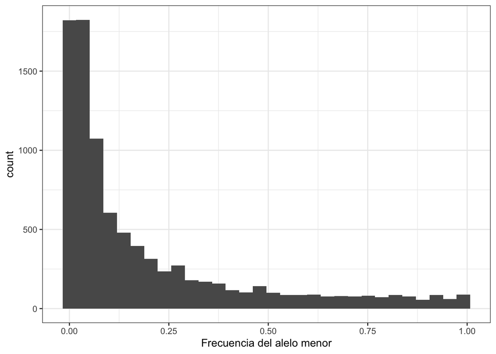

```r
ggplot(misfrq_tidy, aes(x=ALLE2.frq)) +  # definimos los datos
          # histograma
          geom_histogram() +
          # títulos bonitos
          xlab("Frecuencia del alelo menor") +
          # quitar fondo gris feo
          theme_bw()
```

**Ejercicio:** utiliza el argumento `binwidth` dentro de `geom_histogram` para disminuir el ancho de las barras.

Por default, el histograma nos da la cuenta (número de datos que caen en cada bin), pero es común quererlo ver en términos de porcentajes. Esto se puede definir especificando que en Y queremos el resutlado de calcular el porcentaje con la siguiente fórmula: `(..count..)/sum(..count..))`, así:

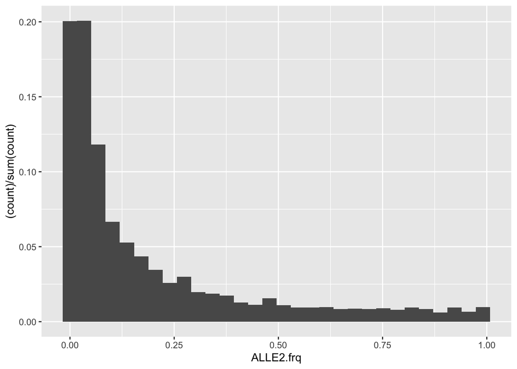

```r
ggplot(misfrq_tidy, aes(x=ALLE2.frq)) +  # definimos los datos
          # histograma
          geom_histogram(aes(y=(..count..)/sum(..count..)))  #en vez de count, queremos usar count para hacer una operación matemática que calcule el porcentaje.
```

**Ejercicio:** modifica la fórmula de Y para que el porcentaje esté expresado en 0-100 en vez de 0-1.

**Ejercicio:** modifica el título de los ejes para que en X diga "Frecuencia alelo menor" y en Y diga: "Porcentaje".

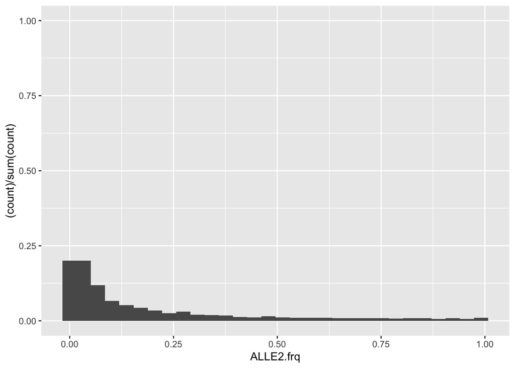

```r
ggplot(misfrq_tidy, aes(x=ALLE2.frq)) +  # definimos los datos
          # histograma con porcentaje en y
          geom_histogram(aes(y=(..count..)/sum(..count..))) +
          # cambiar limites de y
          ylim(0,1)
```

## Espectro de frecuencias de los alelos calculado con Stacks

[Stacks](https://catchenlab.life.illinois.edu/stacks/) es un software para ensamblar datos de representación reducida de genomas (GBS, RADseq y amigos) tanto *de novo* como con genoma de referencia. Además de ensamblar y llamar SNPs, Stacks permite hacer una serie de análisis de genética de poblaciones con el subprograma [populations](https://catchenlab.life.illinois.edu/stacks/comp/populations.php) .

El output son una serie de archivos txt con estadísticos resumen a nivel de población o de locus. El que nos interesa para hacer un plot del espectro de frecuencias es [populations.sumstats.tsv:](https://catchenlab.life.illinois.edu/stacks/manual/#pfiles). En el archivo batch_1.sumstats.tsv puedes ver un archivo output real, proviene del repositorio:

Mastretta-Yanes, Alicia et al. (2014), Data from: Gene duplication, population genomics and species-level differentiation within a tropical mountain shrub, Dryad, Dataset, https://doi.org/10.5061/dryad.n3jk5

### Cargar y limpiar datos

Primero descarga el archivo batch_1.sumstats.tsv aquí.

Para leer los datos, es necesario saltarse las primeras filas del archivo, porque contiene el nombre de las muestras de cada población:

```r
sumstats<-read.delim("batch_1.sumstats.tsv",
                     skip=9)
head(sumstats)
```

```
##   X..Batch.ID Locus.ID Chr BP Col Pop.ID P.Nuc Q.Nuc  N        P  Obs.Het
## 1           1        2  un 10   9      1     A     T 10 0.900000 0.000000
## 2           1        2  un 10   9      2     A        9 1.000000 0.000000
## 3           1        2  un 10   9      3     A       10 1.000000 0.000000
## 4           1        2  un 10   9      4     A     T  6 0.666667 0.333333
## 5           1        2  un 10   9      5     A        6 1.000000 0.000000
## 6           1        2  un 10   9      6     A     T  6 0.916667 0.166667
##    Obs.Hom  Exp.Het  Exp.Hom       Pi Smoothed.Pi Smoothed.Pi.P.value    Fis
## 1 1.000000 0.180000 0.810526 0.189474           0                   0 1.0000
## 2 1.000000 0.000000 1.000000 0.000000           0                   0 0.0000
## 3 1.000000 0.000000 1.000000 0.000000           0                   0 0.0000
## 4 0.666667 0.444444 0.515152 0.484848           0                   0 0.3125
## 5 1.000000 0.000000 1.000000 0.000000           0                   0 0.0000
## 6 0.833333 0.152778 0.833333 0.166667           0                   0 0.0000
##   Smoothed.Fis Smoothed.Fis.P.value Private
## 1            0                    0       0
## 2            0                    0       0
## 3            0                    0       0
## 4            0                    0       0
## 5            0                    0       0
## 6            0                    0       0
```

Como sabemos que el Pop.ID corresponde a una determinada población, podemos cambiar el ID numérico por el nombre de la población (cuyas muestras sabemos por las líneas que omitos del archivo sumstats).

```r
# volver factor Pop.ID
sumstats$Pop.ID<-as.factor(sumstats$Pop.ID)

# ver cómo quedó
head(sumstats$Pop.ID)
```

```
## [1] 1 2 3 4 5 6
## Levels: 1 2 3 4 5 6 7 8 9
```

```r
## Cambiar los levels por nombres de las poblaciones (yo conozco los datos y sé que son estos, pero puedes ver en las líneas que omitimos que son las letras con las que empieza cada muestra)

# levels originales
levels(sumstats$Pop.ID)
```

```
## [1] "1" "2" "3" "4" "5" "6" "7" "8" "9"
```

```r
# sobreescribir levels con los nuevos
levels(sumstats$Pop.ID)<-c("Aj", "An", "Iz", "Ma", "Pe", "Tl", "To", "Za", "Out")

# revisar levels y datos
levels(sumstats$Pop.ID)
```

```
## [1] "Aj"  "An"  "Iz"  "Ma"  "Pe"  "Tl"  "To"  "Za"  "Out"
```

```r
head(sumstats)
```

```
##   X..Batch.ID Locus.ID Chr BP Col Pop.ID P.Nuc Q.Nuc  N        P  Obs.Het
## 1           1        2  un 10   9     Aj     A     T 10 0.900000 0.000000
## 2           1        2  un 10   9     An     A        9 1.000000 0.000000
## 3           1        2  un 10   9     Iz     A       10 1.000000 0.000000
## 4           1        2  un 10   9     Ma     A     T  6 0.666667 0.333333
## 5           1        2  un 10   9     Pe     A        6 1.000000 0.000000
## 6           1        2  un 10   9     Tl     A     T  6 0.916667 0.166667
##    Obs.Hom  Exp.Het  Exp.Hom       Pi Smoothed.Pi Smoothed.Pi.P.value    Fis
## 1 1.000000 0.180000 0.810526 0.189474           0                   0 1.0000
## 2 1.000000 0.000000 1.000000 0.000000           0                   0 0.0000
## 3 1.000000 0.000000 1.000000 0.000000           0                   0 0.0000
## 4 0.666667 0.444444 0.515152 0.484848           0                   0 0.3125
## 5 1.000000 0.000000 1.000000 0.000000           0                   0 0.0000
## 6 0.833333 0.152778 0.833333 0.166667           0                   0 0.0000
##   Smoothed.Fis Smoothed.Fis.P.value Private
## 1            0                    0       0
## 2            0                    0       0
## 3            0                    0       0
## 4            0                    0       0
## 5            0                    0       0
## 6            0                    0       0
```

### Graficar espectro de frecuencias

Como puedes leer en la [documentación de populations.sumstats.tsv:](https://catchenlab.life.illinois.edu/stacks/manual/#pfiles), la columna "**P**" contiene la frecuencia del alelo más frecuente.

Hagamos un primer histograma:

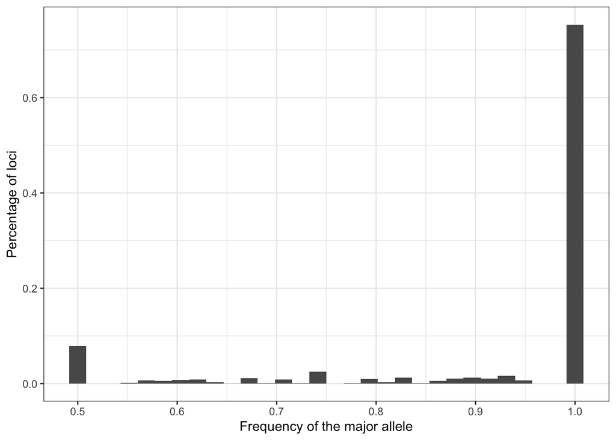

```r
plt<-ggplot(data = sumstats, aes(x = P)) + theme_bw() +
# histograma con porcentaje en y
 geom_histogram(aes(y=(..count..)/sum(..count..))) +
# renombrar ejes
ylab("Percentage of loci") + xlab("Frequency of the major allele")

plt
```

Claramente necesitamos arreglar el número de bins para que se vea mejor:

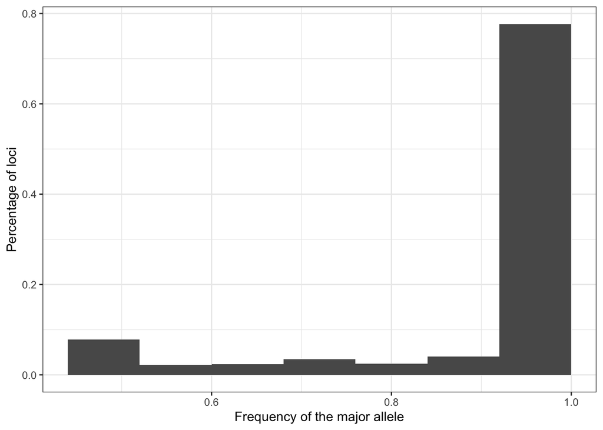

```r
plt<-ggplot(data = sumstats, aes(x = P)) + theme_bw() +
# histograma con porcentaje en y
geom_histogram(aes(y=(..count..)/sum(..count..)),
               binwidth = 0.08) +
# renombrar ejes
ylab("Percentage of loci") + xlab("Frequency of the major allele")
plt
```

Recordemos que tenemos info por población, entonces podemos ver cómo se ve dentro de cada población:

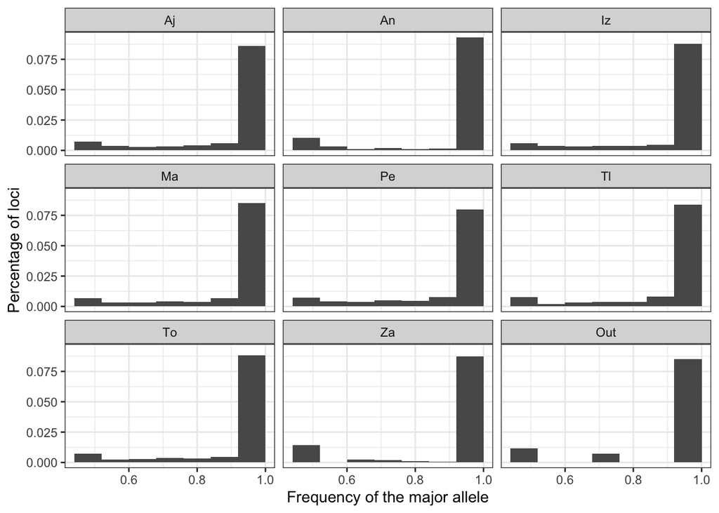

```r
plt + facet_wrap(~Pop.ID)
```

Analiza con cuidado las dos últimas gráficas, en particular la cantidad de loci donde la frecuencia del alelo major es = 0.5 ¿Notas algo raro?

Lee el artículo [Gene Duplication, Population Genomics, and Species-Level Differentiation within a Tropical Mountain Shrub](https://doi.org/10.1093/gbe/evu205) para averiguar más.